# Analyses Printed Summary

Sophia

2023-12-29

# Methods Both Experiments

Number of Sampled, Excluded and Analysed Participants and Trials

| Experiment | Condition | Sampled Participants | Sampled Trials | Time on Task > 40min Participants | Time on Task > 40min Trials | Reading Time < Cut-Off Participants | Reading Time < Cut-Off Trials | Analyzed Participants | Analyzed Trials |
| --- | --- | --- | --- | --- | --- | --- | --- | --- | --- |
| 1 | No-SSI | 62 | 372 | 6 | 36 | 9 | 70 (54 + 16) | 47 | 266 |
| 1 | SSI | 63 | 378 | 5 | 30 | 7 | 48 (42 + 6) | 51 | 301 |
| 2 | Diagramming-Only | 66 | 396 | 3 | 18 | 7 | 54 (42 + 12) | 56 | 324 |
| 2 | No-SSI | 66 | 396 | 3 | 18 | 3 | 32 (18 + 14) | 60 | 346 |
| 2 | SSI | 67 | 402 | 2 | 12 | 4 | 33 (24 + 9) | 61 | 357 |

Age Distribution of Experiment 1 and 2

| Experiment | Mean | SD |
| --- | --- | --- |
| 1 | 14.00 | 1.30 |
| 2 | 14.25 | 1.27 |

Gender Distribution of Experiment 1 and 2

| Experiment | Gender | n | % |
| --- | --- | --- | --- |
| 1 | Female | 43 | 43.88 |
| 1 | Male | 52 | 53.06 |
| 1 | Not specified | 3 | 3.06 |
| 2 | Female | 73 | 41.24 |
| 2 | Male | 101 | 57.06 |
| 2 | Not specified | 3 | 1.69 |

Time on Task Per Condition and Experiment

| Experiment | Condition | Mean | SD | Min | Max |
| --- | --- | --- | --- | --- | --- |
| 1 | No-SSI | 25.66 | 5.21 | 12.78 | 36.92 |
| 1 | SSI | 26.24 | 5.64 | 12.48 | 39.58 |
| 1 | Total Exp.1 | 25.97 | 5.44 | 12.48 | 39.58 |
| 2 | Diagramming-Only | 26.60 | 5.51 | 14.75 | 39.20 |
| 2 | No-SSI | 26.01 | 5.90 | 12.87 | 39.78 |
| 2 | SSI | 26.22 | 5.30 | 14.70 | 39.58 |
| 2 | Total Exp.2 | 26.18 | 5.58 | 12.87 | 39.78 |

Coding 20% of the diagram data and 20% of the test data, the first author and a colleague reached an inter-rater reliability (weighted squared kappa; Vanbelle, 2016; *κ*) of .85 for the diagram data, and .95 for the test data.

# Results Both Experiments

## Manipulation Check: Self-Scoring Evaluation

Self-Scoring Evalutaion - Students Scoring Matching Official Coding

| Experiment |  | Overall n | Overall % | Correctly Completed n | Correctly Completed % | Commission n | Commission % | Omission n | Omission % |
| --- | --- | --- | --- | --- | --- | --- | --- | --- | --- |
| 1 | Incorrect Self-Scores | 195 | 32.34 | 79 | 25.82 | 56 | 41.48 | 1 | 0.97 |
| 1 | Correct Self-Scores | 408 | 67.66 | 227 | 74.18 | 79 | 58.52 | 102 | 99.03 |
| 2 | Incorrect Self-Scores | 190 | 26.24 | 109 | 25.41 | 54 | 31.03 | 1 | 1.05 |
| 2 | Correct Self-Scores | 534 | 73.76 | 320 | 74.59 | 120 | 68.97 | 94 | 98.95 |

## Descriptive Statistics Exp.1 and 2

Descriptive Statistics of Monitoring Accuracy, Text Comprehension and JOLs for Exp. 1 & 2

| Experiment | Phase | Condition | Abs. Monitoring Acc. Mean | Abs. Monitoring Acc. SD | Abs. Monitoring Acc. Min | Abs. Monitoring Acc. Max | Text Comprehension Mean | Text Comprehension SD | Text Comprehension Min | Text Comprehension Max | JOLs Mean | JOLs SD | JOLs Min | JOLs Max |
| --- | --- | --- | --- | --- | --- | --- | --- | --- | --- | --- | --- | --- | --- | --- |
| 1 | 1 | SSI | 0.84 | 0.41 | 0.00 | 1.67 | 2.40 | 0.96 | 0.33 | 4.00 | 2.31 | 0.71 | 0.33 | 3.67 |
| 1 | 1 | No-SSI | 0.89 | 0.47 | 0.00 | 1.67 | 2.51 | 0.89 | 0.50 | 4.00 | 2.40 | 0.63 | 0.67 | 3.50 |
| 1 | 1 |  | 0.86 | 0.44 | 0.00 | 1.67 | 2.45 | 0.92 | 0.33 | 4.00 | 2.35 | 0.67 | 0.33 | 3.67 |
| 1 | 2 | SSI | 1.02 | 0.56 | 0.00 | 3.00 | 2.24 | 1.03 | 0.00 | 4.00 | 2.21 | 0.76 | 0.33 | 4.00 |
| 1 | 2 | No-SSI | 1.07 | 0.53 | 0.00 | 2.33 | 2.40 | 0.87 | 0.50 | 4.00 | 2.07 | 0.77 | 0.33 | 3.67 |
| 1 | 2 |  | 1.05 | 0.54 | 0.00 | 3.00 | 2.31 | 0.95 | 0.00 | 4.00 | 2.14 | 0.76 | 0.33 | 4.00 |
| 1 |  | SSI | 0.92 | 0.34 | 0.00 | 2.00 | 2.32 | 0.80 | 0.33 | 4.00 | 2.26 | 0.59 | 1.00 | 3.83 |
| 1 |  | No-SSI | 0.98 | 0.32 | 0.33 | 1.67 | 2.45 | 0.71 | 0.50 | 4.00 | 2.24 | 0.57 | 0.67 | 3.50 |
| 1 |  |  | 0.95 | 0.33 | 0.00 | 2.00 | 2.39 | 0.76 | 0.33 | 4.00 | 2.25 | 0.58 | 0.67 | 3.83 |
| 2 | 1 | SSI | 1.01 | 0.52 | 0.00 | 3.00 | 2.84 | 0.70 | 1.33 | 4.00 | 2.39 | 0.72 | 0.67 | 4.00 |
| 2 | 1 | No-SSI | 0.97 | 0.52 | 0.00 | 3.00 | 2.72 | 0.90 | 1.00 | 4.00 | 2.46 | 0.68 | 0.67 | 4.00 |
| 2 | 1 | Diagramming-Only | 0.89 | 0.46 | 0.00 | 2.00 | 2.35 | 0.85 | 0.00 | 4.00 | 2.51 | 0.68 | 0.00 | 4.00 |
| 2 | 1 |  | 0.96 | 0.50 | 0.00 | 3.00 | 2.64 | 0.84 | 0.00 | 4.00 | 2.45 | 0.69 | 0.00 | 4.00 |
| 2 | 2 | SSI | 0.98 | 0.51 | 0.00 | 2.67 | 2.78 | 0.82 | 0.33 | 4.00 | 2.58 | 0.80 | 0.00 | 4.00 |
| 2 | 2 | No-SSI | 1.08 | 0.65 | 0.00 | 3.00 | 2.66 | 0.91 | 0.33 | 4.00 | 2.48 | 0.70 | 0.67 | 4.00 |
| 2 | 2 | Diagramming-Only | 1.00 | 0.74 | 0.00 | 4.00 | 2.03 | 0.78 | 0.00 | 3.67 | 2.61 | 0.78 | 0.00 | 4.00 |
| 2 | 2 |  | 1.02 | 0.63 | 0.00 | 4.00 | 2.51 | 0.90 | 0.00 | 4.00 | 2.56 | 0.76 | 0.00 | 4.00 |
| 2 |  | SSI | 1.00 | 0.38 | 0.17 | 2.00 | 2.81 | 0.61 | 1.33 | 4.00 | 2.49 | 0.65 | 0.83 | 4.00 |
| 2 |  | No-SSI | 1.02 | 0.40 | 0.17 | 2.17 | 2.67 | 0.81 | 0.67 | 4.00 | 2.46 | 0.56 | 1.00 | 3.67 |
| 2 |  | Diagramming-Only | 0.94 | 0.45 | 0.25 | 2.75 | 2.21 | 0.62 | 0.50 | 3.50 | 2.56 | 0.60 | 0.75 | 3.50 |
| 2 |  |  | 0.99 | 0.41 | 0.17 | 2.75 | 2.57 | 0.73 | 0.50 | 4.00 | 2.50 | 0.60 | 0.75 | 4.00 |

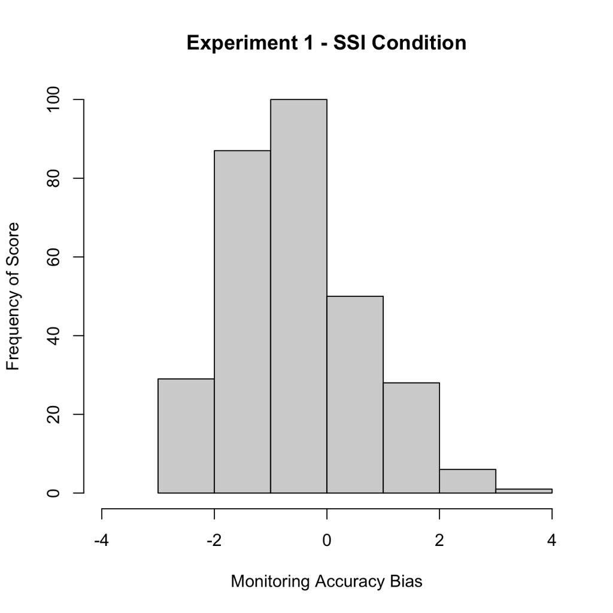

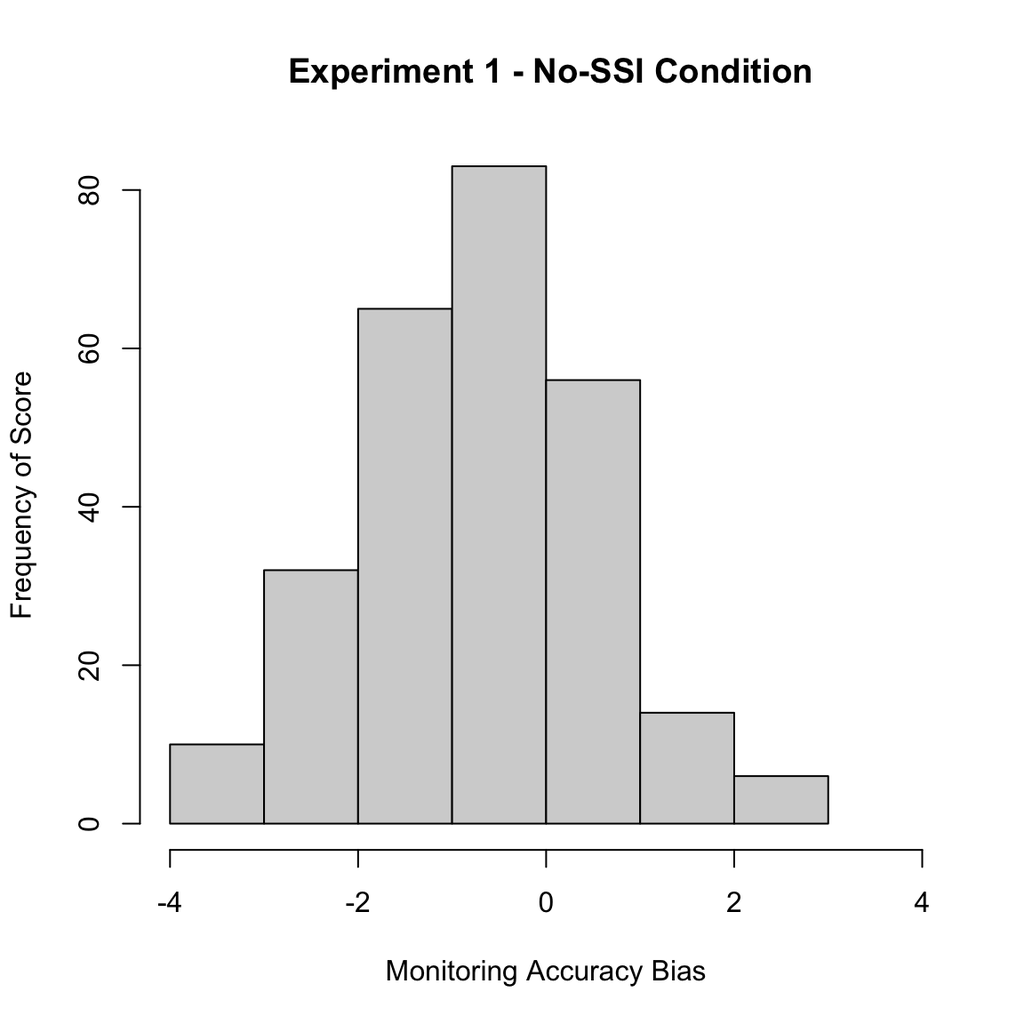

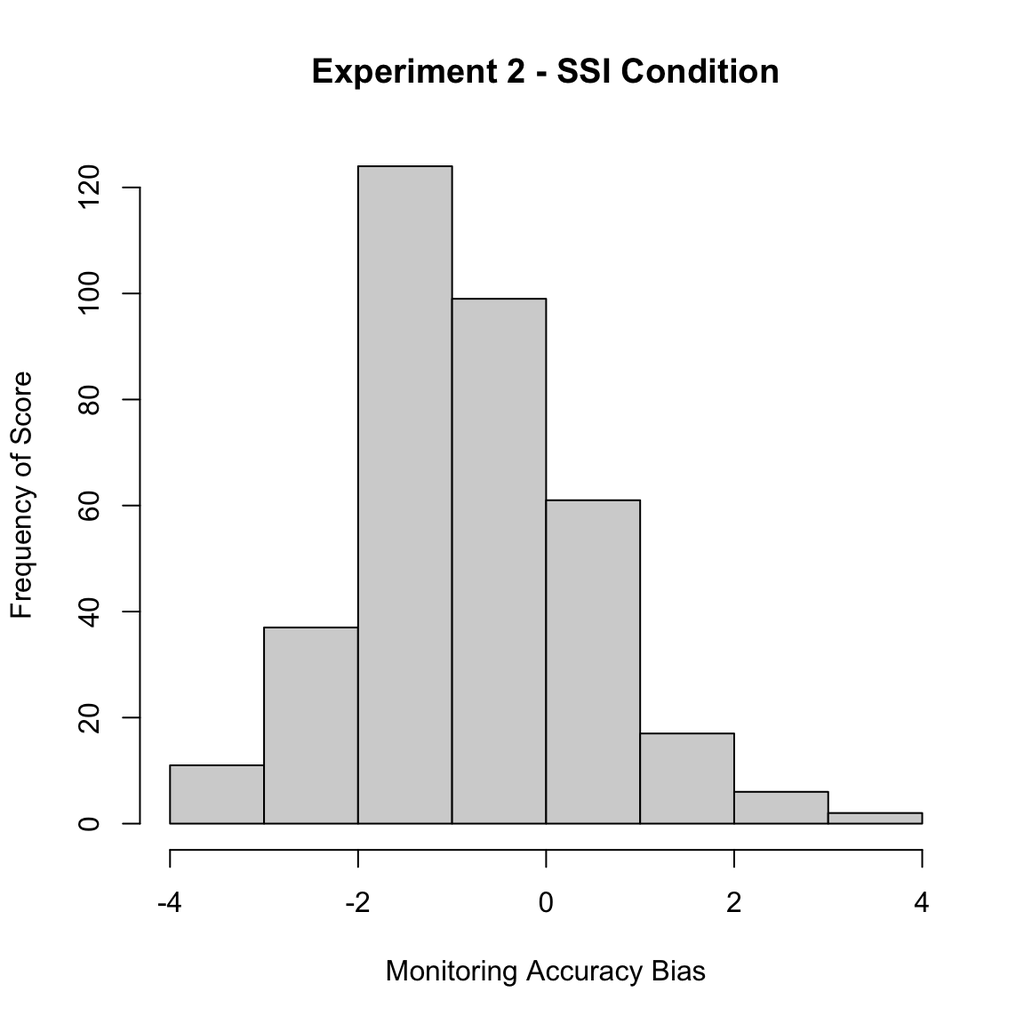

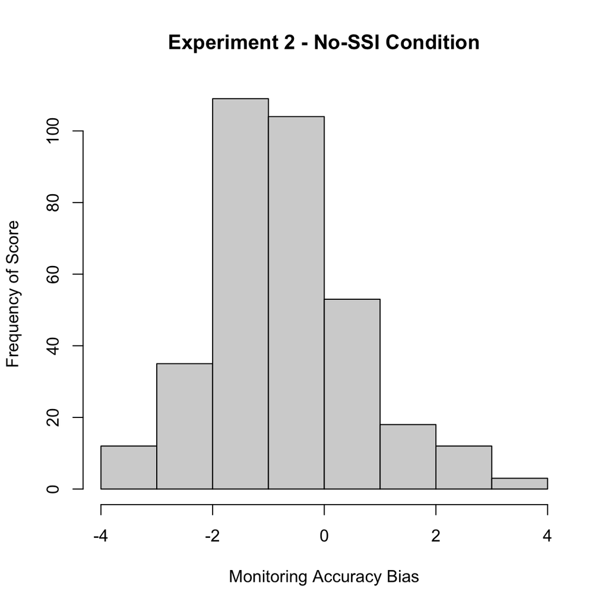

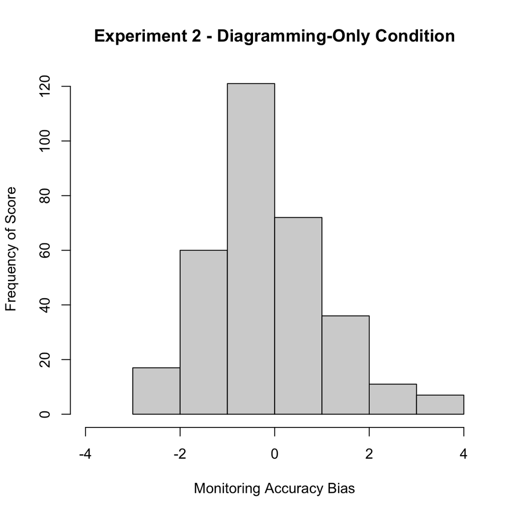

# Results Experiment 1

## Monitoring Accuracy

|  | Abs_Mon_Acc |  |  |  |  |  |  |  | Abs_Mon_Acc |  |  |  |  |  |  |
| --- | --- | --- | --- | --- | --- | --- | --- | --- | --- | --- | --- | --- | --- | --- | --- |
| Predictors | Estimates | std. Error | std. Beta | standardized std. Error | CI | standardized CI | p | std. p | Estimates | std. Error | std. Beta | standardized std. Error | CI | standardized CI | p |
| (Intercept) | 0.69 | 0.16 | 0.04 | 0.06 | 0.38 – 1.01 | -0.08 – 0.16 | **<0.001** | 0.523 | 0.71 | 0.12 | 0.04 | 0.06 | 0.48 – 0.94 | -0.08 – 0.16 | **<0.001** |
| Condition [SSI] | -0.04 | 0.22 | -0.07 | 0.08 | -0.47 – 0.40 | -0.24 – 0.09 | 0.871 | 0.381 | -0.06 | 0.07 | -0.07 | 0.08 | -0.20 – 0.08 | -0.24 – 0.09 | 0.381 |
| Phase | 0.20 | 0.10 | 0.12 | 0.06 | -0.01 – 0.40 | -0.00 – 0.24 | 0.058 | 0.058 | 0.19 | 0.07 | 0.11 | 0.04 | 0.05 – 0.32 | 0.03 – 0.19 | **0.008** |
| Condition [SSI] × Phase | -0.02 | 0.14 | -0.01 | 0.08 | -0.29 – 0.26 | -0.17 – 0.15 | 0.903 | 0.903 |  |  |  |  |  |  |  |
| Random Effects |  |  |  |  |  |  |  |  |  |  |  |  |  |  |  |
| σ<sup>2</sup> | 0.70 |  |  |  |  |  |  |  | 0.70 |  |  |  |  |  |  |
| τ<sub>00</sub> | 0.00 <sub>Participant_Private_ID:Class_ID</sub> |  |  |  |  |  |  |  | 0.00 <sub>Participant_Private_ID:Class_ID</sub> |  |  |  |  |  |  |
|  | 0.00 <sub>Class_ID</sub> |  |  |  |  |  |  |  | 0.00 <sub>Class_ID</sub> |  |  |  |  |  |  |
| N | 98 <sub>Participant_Private_ID</sub> |  |  |  |  |  |  |  | 98 <sub>Participant_Private_ID</sub> |  |  |  |  |  |  |
|  | 7 <sub>Class_ID</sub> |  |  |  |  |  |  |  | 7 <sub>Class_ID</sub> |  |  |  |  |  |  |
| Observations | 567 |  |  |  |  |  |  |  | 567 |  |  |  |  |  |  |
| Marginal R<sup>2</sup> / Conditional R<sup>2</sup> | 0.013 / NA |  |  |  |  |  |  |  | 0.013 / NA |  |  |  |  |  |  |

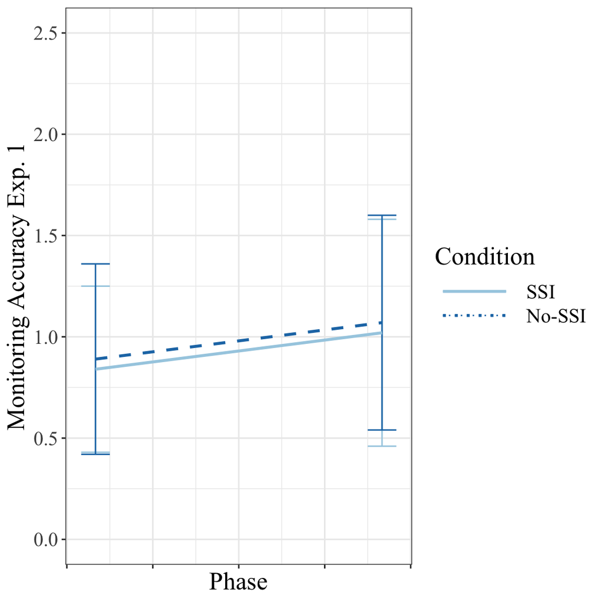

The model with the interaction did not explain significantly more variance compared to the model fitting only main effects *Chi<sup>2</sup>*(1) = 0.01 *p* < 0.903. The main effects model explained 1.35% of the observed variance.

Testing the hypothesis of no differences in students’ mean monitoring accuracy across six trials between Phase 1 and 2 in the SSI condition, showed a Bayes factor of 1, suggesting weak evidence for the alternative hypothesis compared to the null hypothesis. Related to our research question, this means that the data is 1 times more likely under the alternative hypothesis (i.e., differences between Phase 1 and 2) compared to the null hypothesis (i.e., no differences in mean absolute monitoring accuracy between Phase 1 and 2).

## Text Comprehension

|  | Test_Total_Correct |  |  |  |  |  |  |  | Test_Total_Correct |  |  |  |  |  |  |
| --- | --- | --- | --- | --- | --- | --- | --- | --- | --- | --- | --- | --- | --- | --- | --- |
| Predictors | Estimates | std. Error | std. Beta | standardized std. Error | CI | standardized CI | p | std. p | Estimates | std. Error | std. Beta | standardized std. Error | CI | standardized CI | p |
| (Intercept) | 2.52 | 0.28 | -0.01 | 0.16 | 1.96 – 3.08 | -0.33 – 0.31 | **<0.001** | 0.949 | 2.56 | 0.24 | -0.01 | 0.16 | 2.08 – 3.04 | -0.33 – 0.31 | **<0.001** |
| Condition [SSI] | -0.05 | 0.30 | -0.10 | 0.11 | -0.65 – 0.54 | -0.31 – 0.11 | 0.867 | 0.344 | -0.12 | 0.13 | -0.10 | 0.11 | -0.38 – 0.13 | -0.31 – 0.11 | 0.344 |
| Phase | -0.10 | 0.13 | -0.04 | 0.05 | -0.36 – 0.16 | -0.15 – 0.07 | 0.464 | 0.464 | -0.12 | 0.09 | -0.05 | 0.04 | -0.30 – 0.06 | -0.12 – 0.02 | 0.174 |
| Condition [SSI] × Phase | -0.05 | 0.18 | -0.02 | 0.07 | -0.41 – 0.31 | -0.16 – 0.12 | 0.786 | 0.786 |  |  |  |  |  |  |  |
| Random Effects |  |  |  |  |  |  |  |  |  |  |  |  |  |  |  |
| σ<sup>2</sup> | 1.18 |  |  |  |  |  |  |  | 1.17 |  |  |  |  |  |  |
| τ<sub>00</sub> | 0.21 <sub>Participant_Private_ID:Class_ID</sub> |  |  |  |  |  |  |  | 0.21 <sub>Participant_Private_ID:Class_ID</sub> |  |  |  |  |  |  |
|  | 0.20 <sub>Class_ID</sub> |  |  |  |  |  |  |  | 0.20 <sub>Class_ID</sub> |  |  |  |  |  |  |
| ICC | 0.26 |  |  |  |  |  |  |  | 0.26 |  |  |  |  |  |  |
| N | 98 <sub>Participant_Private_ID</sub> |  |  |  |  |  |  |  | 98 <sub>Participant_Private_ID</sub> |  |  |  |  |  |  |
|  | 7 <sub>Class_ID</sub> |  |  |  |  |  |  |  | 7 <sub>Class_ID</sub> |  |  |  |  |  |  |
| Observations | 567 |  |  |  |  |  |  |  | 567 |  |  |  |  |  |  |
| Marginal R<sup>2</sup> / Conditional R<sup>2</sup> | 0.005 / 0.264 |  |  |  |  |  |  |  | 0.005 / 0.265 |  |  |  |  |  |  |

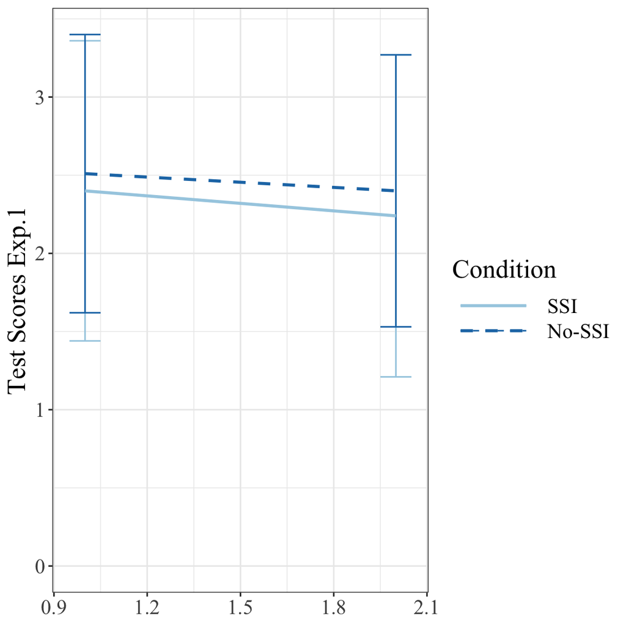

The model with the interaction did not explain significantly more variance compared to the model fitting only main effects *Chi<sup>2</sup>*(1) = 0.07 *p* = 0.787. The main effects model explained 25.49% of the observed variance.

## Restudy Decisions

|  | Rel_Restudy_Acc_MA |  |  |
| --- | --- | --- | --- |
| Predictors | Estimates | CI | p |
| (Intercept) | 0.83 | 0.61 – 1.04 | **<0.001** |
| Condition [SSI] | -0.25 | -0.57 – 0.06 | 0.106 |
| Observations | 62 |  |  |
| R<sup>2</sup> / R<sup>2</sup> adjusted | 0.043 / 0.027 |  |  |

```
##
## Call:
## lm(formula = Rel_Restudy_Acc_MA ~ Condition, data = row_per_participant_data_exp1)
##
## Residuals:
##      Min       1Q   Median       3Q      Max
## -1.82545  0.09598  0.17455  0.42928  0.42928
##
## Coefficients:
##              Estimate Std. Error t value Pr(>|t|)
## (Intercept)    0.8254     0.1080   7.645 1.98e-10 ***
## ConditionSSI  -0.2547     0.1552  -1.641    0.106
## ---
## Signif. codes:  0 '***' 0.001 '**' 0.01 '*' 0.05 '.' 0.1 ' ' 1
##
## Residual standard error: 0.6108 on 60 degrees of freedom
##   (36 observations deleted due to missingness)
## Multiple R-squared:  0.04296,    Adjusted R-squared:  0.027
## F-statistic: 2.693 on 1 and 60 DF,  p-value: 0.106
```

|  | Rel_Restudy_Acc_TC |  |  |
| --- | --- | --- | --- |
| Predictors | Estimates | CI | p |
| (Intercept) | 0.36 | 0.12 – 0.61 | **0.005** |
| Condition [SSI] | 0.08 | -0.28 – 0.43 | 0.659 |
| Observations | 60 |  |  |
| R<sup>2</sup> / R<sup>2</sup> adjusted | 0.003 / -0.014 |  |  |

```
##
## Call:
## lm(formula = Rel_Restudy_Acc_TC ~ Condition, data = row_per_participant_data_exp1)
##
## Residuals:
##     Min      1Q  Median      3Q     Max
## -1.4439 -0.3847  0.1956  0.5758  0.6350
##
## Coefficients:
##              Estimate Std. Error t value Pr(>|t|)
## (Intercept)   0.36498    0.12354   2.954  0.00452 **
## ConditionSSI  0.07894    0.17771   0.444  0.65852
## ---
## Signif. codes:  0 '***' 0.001 '**' 0.01 '*' 0.05 '.' 0.1 ' ' 1
##
## Residual standard error: 0.6879 on 58 degrees of freedom
##   (38 observations deleted due to missingness)
## Multiple R-squared:  0.003391,   Adjusted R-squared:  -0.01379
## F-statistic: 0.1973 on 1 and 58 DF,  p-value: 0.6585
```

## Cue Values

Descriptive Statistics Cue Values, Cue Diagnosticity and Cue Utilization

| Experiment | Condition | Correct Mean | Correct SD | Correct Min | Correct Max | Correct NAs | Commission Mean | Commission SD | Commission Min | Commission Max | Commission NAs | Omission Mean | Omission SD | Omission Min | Omission Max | Omission NAs |
| --- | --- | --- | --- | --- | --- | --- | --- | --- | --- | --- | --- | --- | --- | --- | --- | --- |
| **Cue Value** |  |  |  |  |  |  |  |  |  |  |  |  |  |  |  |  |
| 1 | No-SSI | 2.03 | 1.14 | 0.00 | 4.00 | 0 | 1.06 | 1.00 | 0.00 | 4.00 | 0 | 0.70 | 1.01 | 0.00 | 4.00 | 0 |
| 1 | SSI | 2.07 | 1.25 | 0.00 | 4.00 | 0 | 0.92 | 0.97 | 0.00 | 4.00 | 0 | 0.72 | 1.12 | 0.00 | 4.00 | 0 |
| 2 | Diagramming-Only | 2.73 | 1.12 | 0.00 | 4.00 | 0 | 0.82 | 0.92 | 0.00 | 4.00 | 0 | 0.52 | 0.89 | 0.00 | 4.00 | 0 |
| 2 | No-SSI | 2.56 | 1.11 | 0.00 | 4.00 | 0 | 0.90 | 0.81 | 0.00 | 4.00 | 0 | 0.63 | 0.92 | 0.00 | 4.00 | 0 |
| 2 | SSI | 2.63 | 1.10 | 0.00 | 4.00 | 0 | 0.93 | 0.92 | 0.00 | 4.00 | 0 | 0.52 | 0.87 | 0.00 | 4.00 | 0 |
| **Cue Diagnosticity** |  |  |  |  |  |  |  |  |  |  |  |  |  |  |  |  |
| 1 | No-SSI | 0.47 | 0.48 | -0.77 | 0.96 | 2 | -0.21 | 0.46 | -0.89 | 0.88 | 2 | -0.32 | 0.47 | -1.00 | 0.79 | 4 |
| 1 | SSI | 0.50 | 0.33 | -0.41 | 0.93 | 2 | -0.10 | 0.41 | -0.91 | 0.66 | 3 | -0.35 | 0.45 | -0.98 | 0.52 | 10 |
| 2 | Diagramming-Only | 0.59 | 0.35 | -0.35 | 1.00 | 1 | -0.22 | 0.45 | -0.96 | 0.91 | 5 | -0.39 | 0.45 | -1.00 | 0.80 | 7 |
| 2 | No-SSI | 0.35 | 0.46 | -0.79 | 0.96 | 1 | -0.17 | 0.43 | -0.94 | 0.84 | 2 | -0.22 | 0.46 | -0.97 | 0.76 | 7 |
| 2 | SSI | 0.40 | 0.43 | -0.85 | 1.00 | 2 | -0.20 | 0.50 | -1.00 | 0.86 | 3 | -0.33 | 0.46 | -0.97 | 0.76 | 12 |
| **Cue Utilization** |  |  |  |  |  |  |  |  |  |  |  |  |  |  |  |  |
| 1 | No-SSI | 0.44 | 0.39 | -0.54 | 0.96 | 0 | -0.10 | 0.48 | -0.93 | 0.74 | 0 | -0.46 | 0.38 | -1.00 | 0.61 | 3 |
| 1 | SSI | 0.53 | 0.39 | -0.66 | 0.96 | 3 | -0.07 | 0.45 | -0.88 | 0.80 | 4 | -0.54 | 0.38 | -0.96 | 0.61 | 10 |
| 2 | Diagramming-Only | 0.40 | 0.44 | -0.67 | 1.00 | 2 | 0.07 | 0.49 | -0.88 | 0.91 | 6 | -0.53 | 0.42 | -1.00 | 0.44 | 8 |
| 2 | No-SSI | 0.43 | 0.48 | -0.73 | 1.00 | 1 | -0.17 | 0.44 | -0.87 | 0.92 | 2 | -0.37 | 0.49 | -0.98 | 1.00 | 7 |
| 2 | SSI | 0.40 | 0.46 | -0.79 | 0.94 | 5 | -0.16 | 0.47 | -0.89 | 0.92 | 6 | -0.41 | 0.42 | -1.00 | 0.71 | 15 |

# Experiment 2

# Monitoring Accuracy

|  | Abs_Mon_Acc |  |  |  |  |  |  |  | Abs_Mon_Acc |  |  |  |  |  |  |
| --- | --- | --- | --- | --- | --- | --- | --- | --- | --- | --- | --- | --- | --- | --- | --- |
| Predictors | Estimates | std. Error | std. Beta | standardized std. Error | CI | standardized CI | p | std. p | Estimates | std. Error | std. Beta | standardized std. Error | CI | standardized CI | p |
| (Intercept) | 0.82 | 0.16 | -0.06 | 0.06 | 0.52 – 1.13 | -0.18 – 0.06 | **<0.001** | 0.313 | 0.86 | 0.10 | -0.06 | 0.06 | 0.67 – 1.05 | -0.18 – 0.06 | **<0.001** |
| Condition [No-SSI] | 0.05 | 0.22 | 0.10 | 0.08 | -0.37 – 0.48 | -0.06 – 0.26 | 0.814 | 0.207 | 0.09 | 0.07 | 0.10 | 0.08 | -0.05 – 0.24 | -0.06 – 0.26 | 0.206 |
| Condition [SSI] | 0.21 | 0.21 | 0.07 | 0.08 | -0.21 – 0.63 | -0.09 – 0.23 | 0.325 | 0.373 | 0.06 | 0.07 | 0.07 | 0.08 | -0.08 – 0.21 | -0.09 – 0.23 | 0.373 |
| Phase | 0.07 | 0.10 | 0.04 | 0.05 | -0.12 – 0.26 | -0.07 – 0.15 | 0.464 | 0.464 | 0.05 | 0.06 | 0.03 | 0.03 | -0.06 – 0.15 | -0.03 – 0.09 | 0.394 |
| Condition [No-SSI] × Phase | 0.03 | 0.14 | 0.02 | 0.08 | -0.24 – 0.30 | -0.13 – 0.17 | 0.839 | 0.839 |  |  |  |  |  |  |  |
| Condition [SSI] × Phase | -0.10 | 0.14 | -0.06 | 0.08 | -0.36 – 0.17 | -0.20 – 0.09 | 0.468 | 0.468 |  |  |  |  |  |  |  |
| Random Effects |  |  |  |  |  |  |  |  |  |  |  |  |  |  |  |
| σ<sup>2</sup> | 0.78 |  |  |  |  |  |  |  | 0.78 |  |  |  |  |  |  |
| τ<sub>00</sub> | 0.02 <sub>Participant_Private_ID</sub> |  |  |  |  |  |  |  | 0.02 <sub>Participant_Private_ID</sub> |  |  |  |  |  |  |
| ICC | 0.03 |  |  |  |  |  |  |  | 0.03 |  |  |  |  |  |  |
| N | 177 <sub>Participant_Private_ID</sub> |  |  |  |  |  |  |  | 177 <sub>Participant_Private_ID</sub> |  |  |  |  |  |  |
| Observations | 1027 |  |  |  |  |  |  |  | 1027 |  |  |  |  |  |  |
| Marginal R<sup>2</sup> / Conditional R<sup>2</sup> | 0.003 / 0.029 |  |  |  |  |  |  |  | 0.003 / 0.028 |  |  |  |  |  |  |

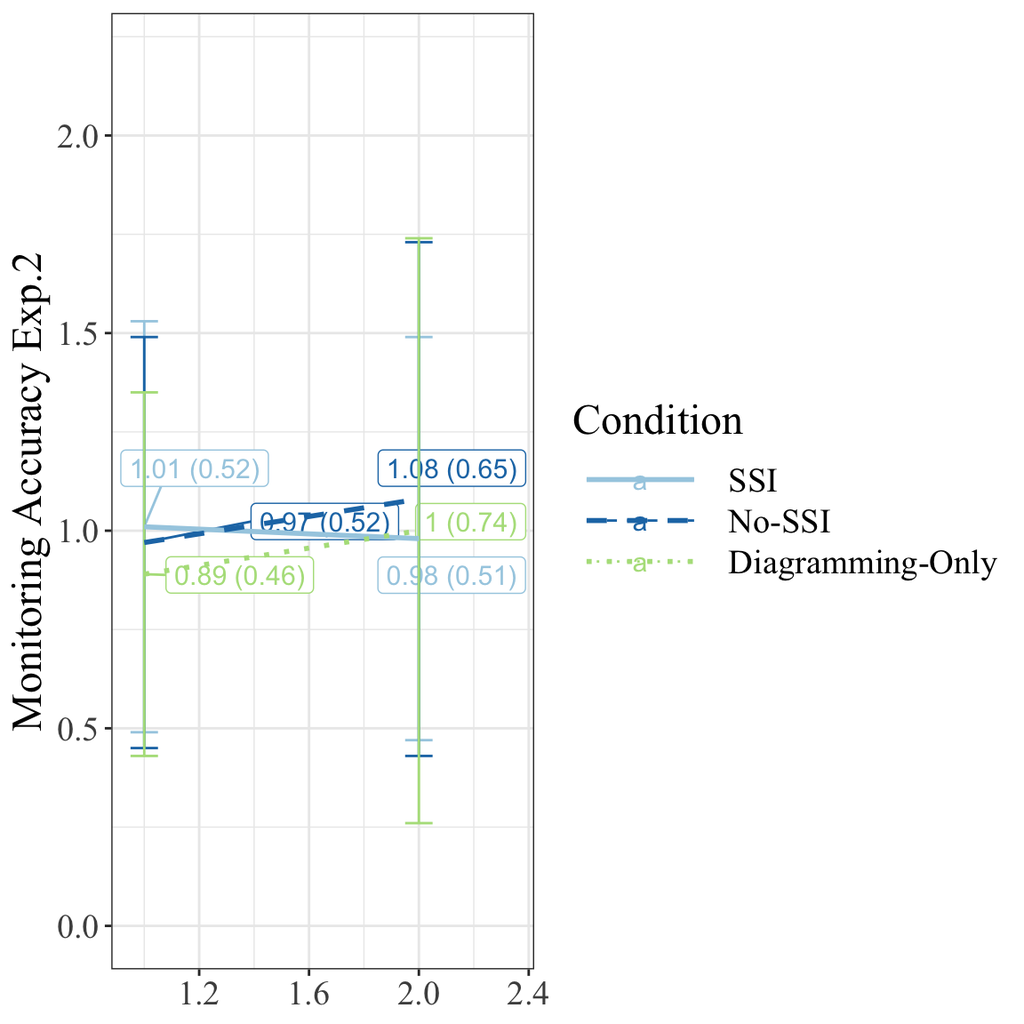

The model with the interaction did not explain significantly more variance compared to the model fitting only main effects *Chi<sup>2</sup>*(2) = 1 *p* = 0.608. The main effects model explained 2.83% of the observed variance.

Testing the hypothesis of no differences between mean absolute monitoring accuracy of students in the SSI condition between Phase 1 and 2, a Bayes Factor of 0.2 suggested moderate evidence against the alternative hypothesis compared to the null hypothesis. This means that the data is about 5 times more likely under the null hypothesis (no differences between monitoring accuracy between Phase 1 and 2) compared to the alternative hypothesis.

## Text Comprehension

|  | Test_Total_Correct |  |  |  |  |  |  |  | Test_Total_Correct |  |  |  |  |  |  |
| --- | --- | --- | --- | --- | --- | --- | --- | --- | --- | --- | --- | --- | --- | --- | --- |
| Predictors | Estimates | std. Error | std. Beta | standardized std. Error | CI | standardized CI | p | std. p | Estimates | std. Error | std. Beta | standardized std. Error | CI | standardized CI | p |
| (Intercept) | 2.63 | 0.22 | -0.31 | 0.09 | 2.20 – 3.06 | -0.50 – -0.13 | **<0.001** | **0.001** | 2.39 | 0.16 | -0.31 | 0.09 | 2.08 – 2.70 | -0.49 – -0.13 | **<0.001** |
| Condition [No-SSI] | 0.14 | 0.29 | 0.39 | 0.09 | -0.42 – 0.70 | 0.21 – 0.57 | 0.632 | **<0.001** | 0.49 | 0.12 | 0.39 | 0.09 | 0.26 – 0.72 | 0.21 – 0.57 | **<0.001** |
| Condition [SSI] | 0.24 | 0.28 | 0.48 | 0.09 | -0.31 – 0.80 | 0.30 – 0.66 | 0.389 | **<0.001** | 0.60 | 0.12 | 0.48 | 0.09 | 0.37 – 0.82 | 0.30 – 0.66 | **<0.001** |
| Phase | -0.29 | 0.13 | -0.12 | 0.05 | -0.54 – -0.05 | -0.22 – -0.02 | **0.019** | **0.019** | -0.13 | 0.07 | -0.05 | 0.03 | -0.27 – 0.01 | -0.11 – 0.00 | 0.061 |
| Condition [No-SSI] × Phase | 0.24 | 0.17 | 0.09 | 0.07 | -0.11 – 0.58 | -0.04 – 0.23 | 0.176 | 0.176 |  |  |  |  |  |  |  |
| Condition [SSI] × Phase | 0.24 | 0.17 | 0.09 | 0.07 | -0.10 – 0.58 | -0.04 – 0.23 | 0.172 | 0.172 |  |  |  |  |  |  |  |
| Random Effects |  |  |  |  |  |  |  |  |  |  |  |  |  |  |  |
| σ<sup>2</sup> | 1.27 |  |  |  |  |  |  |  | 1.27 |  |  |  |  |  |  |
| τ<sub>00</sub> | 0.17 <sub>Participant_Private_ID:Class_ID</sub> |  |  |  |  |  |  |  | 0.17 <sub>Participant_Private_ID:Class_ID</sub> |  |  |  |  |  |  |
|  | 0.07 <sub>Class_ID</sub> |  |  |  |  |  |  |  | 0.07 <sub>Class_ID</sub> |  |  |  |  |  |  |
| ICC | 0.16 |  |  |  |  |  |  |  | 0.16 |  |  |  |  |  |  |
| N | 177 <sub>Participant_Private_ID</sub> |  |  |  |  |  |  |  | 177 <sub>Participant_Private_ID</sub> |  |  |  |  |  |  |
|  | 12 <sub>Class_ID</sub> |  |  |  |  |  |  |  | 12 <sub>Class_ID</sub> |  |  |  |  |  |  |
| Observations | 1028 |  |  |  |  |  |  |  | 1028 |  |  |  |  |  |  |
| Marginal R<sup>2</sup> / Conditional R<sup>2</sup> | 0.046 / 0.197 |  |  |  |  |  |  |  | 0.044 / 0.196 |  |  |  |  |  |  |

| contrast | estimate | SE | df | t.ratio | p.value | effect.size |
| --- | --- | --- | --- | --- | --- | --- |
| Diagramming-Only - No-SSI | -0.49 | 0.12 | 167.33 | -4.21 | 0 | -0.43 |
| Diagramming-Only - SSI | -0.60 | 0.12 | 165.34 | -5.14 | 0 | -0.53 |
| No-SSI - SSI | -0.11 | 0.11 | 166.56 | -0.94 | 1 | -0.09 |

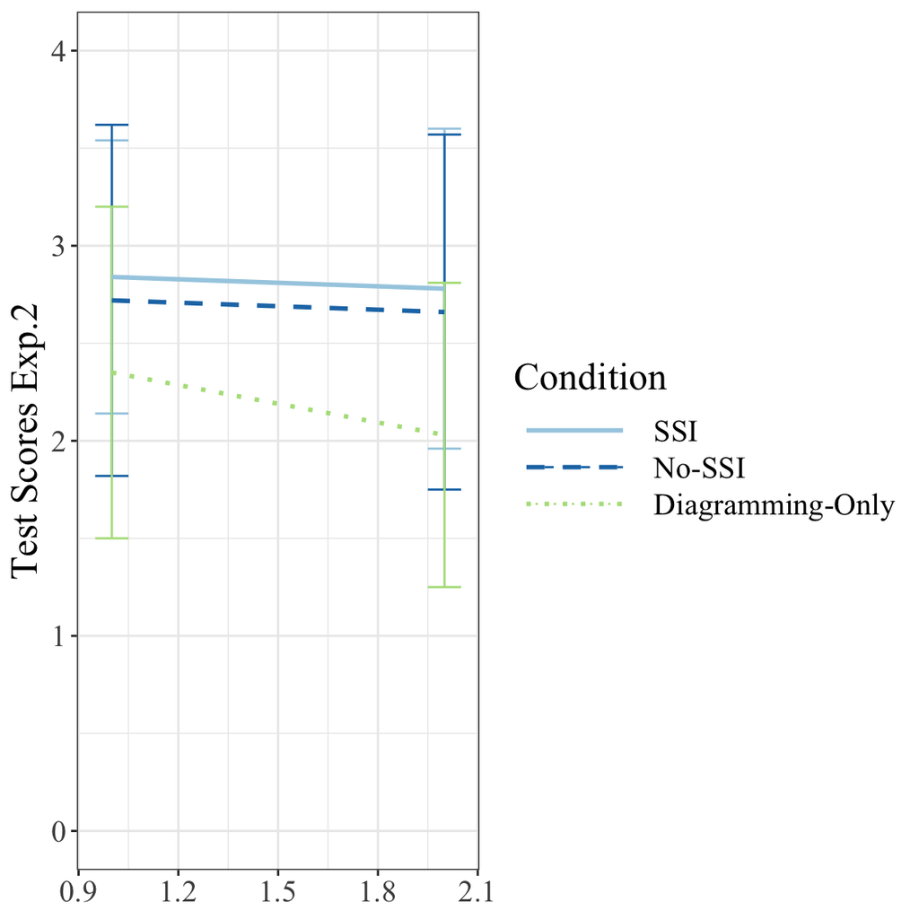

The model with the interaction did not explain significantly more variance compared to the model fitting only main effects *Chi<sup>2</sup>*(2) = 2.45 *p* = 0.294. The main effects model explained 19.26% of the observed variance.

## Restudy Decisions

|  | Rel_Restudy_Acc_MA |  |  |
| --- | --- | --- | --- |
| Predictors | Estimates | CI | p |
| (Intercept) | 0.66 | 0.44 – 0.87 | **<0.001** |
| Condition [No-SSI] | 0.09 | -0.20 – 0.38 | 0.546 |
| Condition [SSI] | -0.18 | -0.48 – 0.12 | 0.229 |
| Observations | 121 |  |  |
| R<sup>2</sup> / R<sup>2</sup> adjusted | 0.030 / 0.014 |  |  |

```
##
## Call:
## lm(formula = Rel_Restudy_Acc_MA ~ Condition, data = row_per_participant_data_exp2)
##
## Residuals:
##     Min      1Q  Median      3Q     Max
## -1.7452 -0.1565  0.2548  0.3435  0.5255
##
## Coefficients:
##                 Estimate Std. Error t value Pr(>|t|)
## (Intercept)       0.6565     0.1092   6.009 2.13e-08 ***
## ConditionNo-SSI   0.0887     0.1466   0.605    0.546
## ConditionSSI     -0.1820     0.1506  -1.208    0.229
## ---
## Signif. codes:  0 '***' 0.001 '**' 0.01 '*' 0.05 '.' 0.1 ' ' 1
##
## Residual standard error: 0.6555 on 118 degrees of freedom
##   (56 observations deleted due to missingness)
## Multiple R-squared:  0.03039,    Adjusted R-squared:  0.01396
## F-statistic: 1.849 on 2 and 118 DF,  p-value: 0.1619
```

|  | Rel_Restudy_Acc_TC |  |  |
| --- | --- | --- | --- |
| Predictors | Estimates | CI | p |
| (Intercept) | 0.35 | 0.15 – 0.55 | **0.001** |
| Condition [No-SSI] | 0.18 | -0.09 – 0.45 | 0.200 |
| Condition [SSI] | 0.09 | -0.19 – 0.36 | 0.541 |
| Observations | 119 |  |  |
| R<sup>2</sup> / R<sup>2</sup> adjusted | 0.014 / -0.003 |  |  |

```
##
## Call:
## lm(formula = Rel_Restudy_Acc_TC ~ Condition, data = row_per_participant_data_exp2)
##
## Residuals:
##     Min      1Q  Median      3Q     Max
## -1.5268 -0.3507  0.1493  0.4732  0.6493
##
## Coefficients:
##                 Estimate Std. Error t value Pr(>|t|)
## (Intercept)      0.35066    0.10145   3.456 0.000766 ***
## ConditionNo-SSI  0.17615    0.13680   1.288 0.200429
## ConditionSSI     0.08634    0.14069   0.614 0.540634
## ---
## Signif. codes:  0 '***' 0.001 '**' 0.01 '*' 0.05 '.' 0.1 ' ' 1
##
## Residual standard error: 0.6087 on 116 degrees of freedom
##   (58 observations deleted due to missingness)
## Multiple R-squared:  0.01416,    Adjusted R-squared:  -0.002839
## F-statistic: 0.833 on 2 and 116 DF,  p-value: 0.4373
```

### *Time on Trial Experiment 2*

```
##
##  Welch Two Sample t-test
##
## data:  Time_On_Trial_min by Trial_Number
## t = 6.9588, df = 221.23, p-value = 3.841e-11
## alternative hypothesis: true difference in means between group 1 and group 6 is not equal to 0
## 95 percent confidence interval:
##  0.7709847 1.3802063
## sample estimates:
## mean in group 1 mean in group 6
##        3.601271        2.525676
```

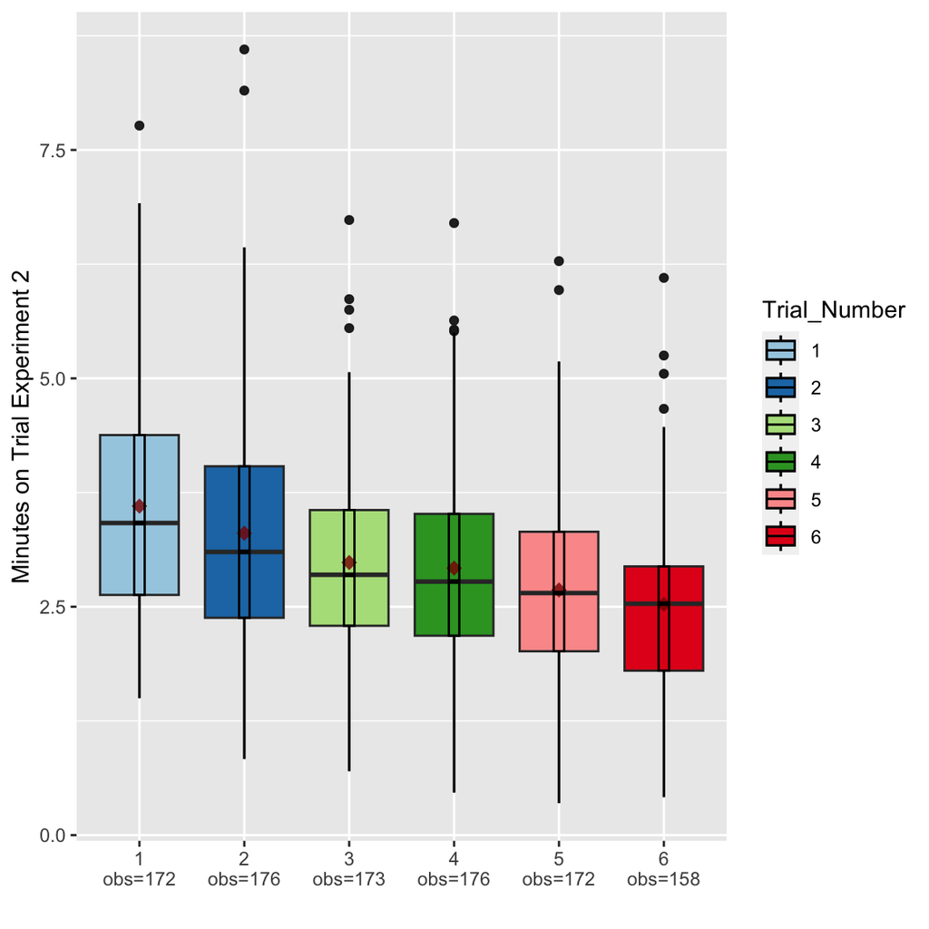

# Experiment 1 vs. Experiment 2

### *We exploratively compared experiments 1 and 2 to investigate differences in monitoring accuracy and text comprehension between students in the delayed and immediate diagramming designs.*

|  | Abs_Mon_Acc |  |  |  |  |  |  |  | Abs_Mon_Acc |  |  |  |  |  |  |
| --- | --- | --- | --- | --- | --- | --- | --- | --- | --- | --- | --- | --- | --- | --- | --- |
| Predictors | Estimates | std. Error | std. Beta | standardized std. Error | CI | standardized CI | p | std. p | Estimates | std. Error | std. Beta | standardized std. Error | CI | standardized CI | p |
| (Intercept) | 0.51 | 0.36 | 0.03 | 0.04 | -0.19 – 1.22 | -0.05 – 0.11 | 0.155 | 0.522 | 0.77 | 0.11 | 0.03 | 0.04 | 0.55 – 0.99 | -0.05 – 0.11 | **<0.001** |
| Experiment | 0.18 | 0.22 | 0.02 | 0.04 | -0.25 – 0.61 | -0.06 – 0.10 | 0.417 | 0.621 | 0.05 | 0.05 | 0.03 | 0.03 | -0.04 – 0.15 | -0.03 – 0.09 | 0.285 |
| Condition [SSI] | -0.23 | 0.50 | -0.05 | 0.06 | -1.21 – 0.74 | -0.16 – 0.06 | 0.641 | 0.377 | -0.04 | 0.05 | -0.05 | 0.06 | -0.14 – 0.05 | -0.16 – 0.06 | 0.379 |
| Phase | 0.29 | 0.23 | 0.08 | 0.04 | -0.16 – 0.74 | 0.00 – 0.16 | 0.204 | **0.041** | 0.10 | 0.05 | 0.06 | 0.03 | 0.01 – 0.20 | 0.00 – 0.11 | **0.034** |
| Experiment × Condition [SSI] | 0.20 | 0.31 | 0.02 | 0.06 | -0.40 – 0.80 | -0.09 – 0.13 | 0.520 | 0.736 |  |  |  |  |  |  |  |
| Experiment × Phase | -0.10 | 0.14 | -0.03 | 0.04 | -0.37 – 0.18 | -0.11 – 0.05 | 0.491 | 0.491 |  |  |  |  |  |  |  |
| Condition [SSI] × Phase | 0.09 | 0.32 | -0.05 | 0.06 | -0.53 – 0.71 | -0.16 – 0.06 | 0.771 | 0.418 |  |  |  |  |  |  |  |
| (Experiment × Condition [SSI]) × Phase | -0.11 | 0.19 | -0.03 | 0.06 | -0.49 – 0.27 | -0.14 – 0.08 | 0.572 | 0.572 |  |  |  |  |  |  |  |
| Random Effects |  |  |  |  |  |  |  |  |  |  |  |  |  |  |  |
| σ<sup>2</sup> | 0.73 |  |  |  |  |  |  |  | 0.73 |  |  |  |  |  |  |
| τ<sub>00</sub> | 0.00 <sub>Participant_Private_ID:Class_ID</sub> |  |  |  |  |  |  |  | 0.00 <sub>Participant_Private_ID:Class_ID</sub> |  |  |  |  |  |  |
|  | 0.00 <sub>Class_ID</sub> |  |  |  |  |  |  |  | 0.00 <sub>Class_ID</sub> |  |  |  |  |  |  |
| N | 219 <sub>Participant_Private_ID</sub> |  |  |  |  |  |  |  | 219 <sub>Participant_Private_ID</sub> |  |  |  |  |  |  |
|  | 18 <sub>Class_ID</sub> |  |  |  |  |  |  |  | 18 <sub>Class_ID</sub> |  |  |  |  |  |  |
| Observations | 1270 |  |  |  |  |  |  |  | 1270 |  |  |  |  |  |  |
| Marginal R<sup>2</sup> / Conditional R<sup>2</sup> | 0.008 / NA |  |  |  |  |  |  |  | 0.005 / NA |  |  |  |  |  |  |

|  | Test_Total_Correct |  |  |  |  |  |  |  | Test_Total_Correct |  |  |  |  |  |  |
| --- | --- | --- | --- | --- | --- | --- | --- | --- | --- | --- | --- | --- | --- | --- | --- |
| Predictors | Estimates | std. Error | std. Beta | standardized std. Error | CI | standardized CI | p | std. p | Estimates | std. Error | std. Beta | standardized std. Error | CI | standardized CI | p |
| (Intercept) | 2.27 | 0.58 | -0.03 | 0.09 | 1.13 – 3.40 | -0.21 – 0.14 | **<0.001** | 0.720 | 2.00 | 0.37 | -0.04 | 0.09 | 1.28 – 2.72 | -0.21 – 0.14 | **<0.001** |
| Experiment | 0.26 | 0.35 | 0.13 | 0.09 | -0.43 – 0.94 | -0.05 – 0.30 | 0.465 | 0.168 | 0.44 | 0.21 | 0.18 | 0.08 | 0.03 – 0.84 | 0.01 – 0.34 | **0.035** |
| Condition [SSI] | -0.21 | 0.66 | 0.00 | 0.07 | -1.51 – 1.08 | -0.14 – 0.14 | 0.745 | 0.997 | 0.00 | 0.09 | 0.00 | 0.07 | -0.17 – 0.17 | -0.14 – 0.14 | 0.993 |
| Phase | -0.14 | 0.29 | -0.03 | 0.04 | -0.71 – 0.43 | -0.10 – 0.04 | 0.639 | 0.384 | -0.09 | 0.06 | -0.04 | 0.02 | -0.21 – 0.03 | -0.08 – 0.01 | 0.150 |
| Experiment × Condition [SSI] | 0.16 | 0.41 | 0.09 | 0.07 | -0.64 – 0.95 | -0.04 – 0.23 | 0.696 | 0.175 |  |  |  |  |  |  |  |
| Experiment × Phase | 0.04 | 0.18 | 0.01 | 0.04 | -0.31 – 0.39 | -0.06 – 0.08 | 0.827 | 0.827 |  |  |  |  |  |  |  |
| Condition [SSI] × Phase | -0.10 | 0.40 | -0.01 | 0.05 | -0.89 – 0.68 | -0.11 – 0.09 | 0.801 | 0.865 |  |  |  |  |  |  |  |
| (Experiment × Condition [SSI]) × Phase | 0.05 | 0.25 | 0.01 | 0.05 | -0.43 – 0.53 | -0.09 – 0.11 | 0.834 | 0.834 |  |  |  |  |  |  |  |
| Random Effects |  |  |  |  |  |  |  |  |  |  |  |  |  |  |  |
| σ<sup>2</sup> | 1.17 |  |  |  |  |  |  |  | 1.17 |  |  |  |  |  |  |
| τ<sub>00</sub> | 0.20 <sub>Participant_Private_ID:Class_ID</sub> |  |  |  |  |  |  |  | 0.20 <sub>Participant_Private_ID:Class_ID</sub> |  |  |  |  |  |  |
|  | 0.15 <sub>Class_ID</sub> |  |  |  |  |  |  |  | 0.15 <sub>Class_ID</sub> |  |  |  |  |  |  |
| ICC | 0.23 |  |  |  |  |  |  |  | 0.23 |  |  |  |  |  |  |
| N | 219 <sub>Participant_Private_ID</sub> |  |  |  |  |  |  |  | 219 <sub>Participant_Private_ID</sub> |  |  |  |  |  |  |
|  | 18 <sub>Class_ID</sub> |  |  |  |  |  |  |  | 18 <sub>Class_ID</sub> |  |  |  |  |  |  |
| Observations | 1271 |  |  |  |  |  |  |  | 1271 |  |  |  |  |  |  |
| Marginal R<sup>2</sup> / Conditional R<sup>2</sup> | 0.033 / 0.252 |  |  |  |  |  |  |  | 0.032 / 0.252 |  |  |  |  |  |  |

# Appendix

Time on Task per Experiment and Condition

| Experiment | Condition | Mean | SD | Min | Max |
| --- | --- | --- | --- | --- | --- |
| 1 | No-SSI | 25.66 | 5.21 | 12.78 | 36.92 |
| 1 | SSI | 26.24 | 5.64 | 12.48 | 39.58 |
| 1 | Total Exp.1 | 25.97 | 5.44 | 12.48 | 39.58 |
| 2 | Diagramming-Only | 26.60 | 5.51 | 14.75 | 39.20 |
| 2 | No-SSI | 26.01 | 5.90 | 12.87 | 39.78 |
| 2 | SSI | 26.22 | 5.30 | 14.70 | 39.58 |
| 2 | Total Exp.2 | 26.18 | 5.58 | 12.87 | 39.78 |

### *Time Diagram Study - Comparisons of First and Last Trial of Experiment 2*

|  | Reaction_Time_min |  |  |
| --- | --- | --- | --- |
| Predictors | Estimates | CI | p |
| (Intercept) | 0.35 | 0.31 – 0.38 | **<0.001** |
| Trial Number [6] | -0.18 | -0.23 – -0.14 | **<0.001** |
| Observations | 229 |  |  |
| R<sup>2</sup> / R<sup>2</sup> adjusted | 0.204 / 0.200 |  |  |

```
##
##  Welch Two Sample t-test
##
## data:  Reaction_Time_min by Trial_Number
## t = 7.7467, df = 188.43, p-value = 5.658e-13
## alternative hypothesis: true difference in means between group 1 and group 6 is not equal to 0
## 95 percent confidence interval:
##  0.1360750 0.2290519
## sample estimates:
## mean in group 1 mean in group 6
##       0.3464743       0.1639109
```

### *Time of Test Compilations - Comparisons of First and Last Trial of Experiment 2*

|  | Reaction_Time_min |  |  |
| --- | --- | --- | --- |
| Predictors | Estimates | CI | p |
| (Intercept) | 1.45 | 1.35 – 1.55 | **<0.001** |
| Trial Number [6] | -0.37 | -0.52 – -0.23 | **<0.001** |
| Observations | 330 |  |  |
| R<sup>2</sup> / R<sup>2</sup> adjusted | 0.070 / 0.067 |  |  |

```
##
##  Welch Two Sample t-test
##
## data:  Reaction_Time_min by Trial_Number
## t = 4.9998, df = 327.76, p-value = 9.367e-07
## alternative hypothesis: true difference in means between group 1 and group 6 is not equal to 0
## 95 percent confidence interval:
##  0.2263998 0.5201319
## sample estimates:
## mean in group 1 mean in group 6
##        1.448842        1.075576
```

…